# R Notebook

En este estudio intentamos encontrar si existe una mejora de la calidad educativa utilizando la *Gamificación* para los estudiantes en UTEC. Para esto, diseñamos un experimento en el que dos grupos (seleccionados por los entrevistadores), uno que utiliza la experiencia tradicional de educación y el otro el cual recibe una educación con un videojuego llamado “Pc building simulator”. Ambos experimentos se diseñaron para durar aproximadamente 15 minutos y se diseñaron para cubrir el mismo material.

Primero la carga de data y la instalación de los paquetes.

```r
library(readr)
library(dplyr)
DF_M <- read_csv("data.csv")
DF_M$`Duración de la experiencia`
```

```
##  [1] "15:35"     "28:25"     "16:25"     "17:15"     "20"        "16:36"
##  [7] "23:21"     "17:20"     "16:40"     "6:40"      "19:25"     "15:25"
## [13] "17:30"     "8 min"     "29:49"     "15:50"     "15:35pm"   "17.35"
## [19] "13:20"     "18:30"     "15:10"     "16:08"     "16:20"     "18:35"
## [25] "17:15"     "14:42"     "25:40"     "18:10"     "24:00"     "18:30"
## [31] "13:47"     "18.15"     "18:35"     "15:08"     "16:58"     "7:33"
## [37] "14:25"     "17:38"     "14:50"     "12:05"     "15:38"     "18.52"
## [43] "18.52"     "25:32"     "18:54"     "20:10"     "17:00"     "16:00"
## [49] "20:10"     "15:10"     "17min"     "15:13"     "20"        "16.41"
## [55] "24:40"     "11:10"     "14:50"     "15 min"    "15"        "17  min"
## [61] "13:20"     "17:20"     "19:20"     "18:15"     "17:30"     "12:10min"
## [67] "9:30"      "18:30"     "27:05"     "12:30"     "14.33"     NA
## [73] "17:20"     "16:00"     "15:20"     "17:32"     "26.20"     "16:05"
## [79] "21:25"     "2 minutos" NA          NA          NA          NA
## [85] NA
```

La cantidad de observaciones que no han sido completadas al 100% son :

```r
Incompletos <-DF_M[!complete.cases(DF_M),]
count(Incompletos)
```

| n |
| --- |
| 22 |

Ahora removemos las columnas que no aportan mucho a el resultado de nuestro experimento:

```r
DF_M$`Submission Date` <- NULL ## La fecha en la que se entrego el test
DF_M$`Nivel de satisfacción al realizar el juego o leer el documento pdf:` <- NULL ## Variable de satisfaccion que no aporta mucho
head(DF_M)
```

| Ingrese su correo de UTEC!! | Nombre | Apellido | ¿Cual es tu edad? | ¿Con que sexo te identificas? | ¿En que ciclo te encuentras? | ¿Cual es tu carrera? | ¿Cuál es tu nivel de experiencia armando computadoras? | ¿Con qué frecuencia juegas videojuegos? | Regula y proporciona la potencia para que se activen todos los componentes de la PC: | Duración de la experiencia | Qué experiencia realizaste: | Cuenta con sus propios procesadores y memoria interna que procesa los datos de la PC y los representa en forma de texto o gráficas complejas como la de los videojuegos. Nos referimos a: | ¿Dónde se conecta o instala la memoria (RAM)? | El CPU se calienta muy rápido; por ello, se le conecta un refrigerador o Cooler para regular el calor de este. Esta afirmación es: | ¿Dónde se coloca la pasta térmica? | Responsable realiza cálculos basados en la interpretación de la información de ciertos componentes y les pasa el resultado a otros. Nos referimos a: | ¿A que parte se conecta el panel frontal de la caja (botón de encendido/apagado, USB, conector de audio, etc)? | Almacena todos los datos del sistema operativo, los programas y las fotos, la música y los vídeos del usuario. Es decir, es el dispositivo de almacenamiento del ordenador. | ¿Cuál es tu nivel de conocimiento (previo a la experiencia) sobre componentes de computadora? |
| --- | --- | --- | --- | --- | --- | --- | --- | --- | --- | --- | --- | --- | --- | --- | --- | --- | --- | --- | --- |
| andrea.vilca@utec.edu.pe | Andrea | Vilca | 22 | Mujer | 9 | Bioingeniería | 1 | No juego videojuegos | Fuente de alimentación (PSU) o sistema de alimentación | 15:35 | Leer Documento PDF | Tarjeta gráfica (GPU) | Caja de la PC | Verdadera | Microchip central (CEM) | Unidad central de procesamiento o Procesador (CPU) | Placa base (Motherboard) | Disco Duro | 4 |
| andrea.castillo@utec.edu.pe | Andrea | Castillo | 24 | Mujer | 5 | Ingeniería Química | 1 | 1 vez por semana | Fuente de alimentación (PSU) o sistema de alimentación | 28:25 | Leer Documento PDF | Tarjeta gráfica (GPU) | Unidad central de procesamiento o Procesador (CPU) | Verdadera | Microchip central (CEM) | Unidad central de procesamiento o Procesador (CPU) | Placa base (Motherboard) | Disco Duro | 2 |
| maria.cardenas@utec.edu.pe | María de los Ángeles Katherine | Cárdenas Zevallos | 20 | Mujer | 7 | Ingeniería Civil | 1 | No juego videojuegos | Fuente de alimentación (PSU) o sistema de alimentación | 16:25 | Leer Documento PDF | Tarjeta gráfica (GPU) | Placa base (Motherboard) | Verdadera | Disco Duro | Microchip central (CEM) | Disco Duro | Memoria (RAM) | 2 |
| jean.santillan@utec.edu.pe | Jean Pierre | Santillan | 20 | Hombre | 6 | Ingeniería Industrial | 5 | 5 veces por semana | Fuente de alimentación (PSU) o sistema de alimentación | 17:15 | Leer Documento PDF | Tarjeta gráfica (GPU) | Placa base (Motherboard) | Verdadera | Unidad central de procesamiento o Procesador (CPU) | Unidad central de procesamiento o Procesador (CPU) | Placa base (Motherboard) | Disco Duro | 5 |
| williams.acevedo@utec.edu.pe | Williams | Acevedo | 21 | Hombre | 8 | Ingeniería Industrial | 1 | 5 veces por semana | Estabilizador (CE) | 20 | Leer Documento PDF | Tarjeta gráfica (GPU) | Placa base (Motherboard) | Verdadera | Microchip central (CEM) | Unidad central de procesamiento o Procesador (CPU) | Placa base (Motherboard) | Disco Duro | 3 |
| camila.sinche@utec.edu.pe | Camila | Sinche | 19 | Mujer | 7 | Ingeniería Química | 1 | 3 veces por semana | Fuente de alimentación (PSU) o sistema de alimentación | 16:36 | Leer Documento PDF | Tarjeta gráfica (GPU) | Placa base (Motherboard) | Verdadera | Unidad central de procesamiento o Procesador (CPU) | Unidad central de procesamiento o Procesador (CPU) | Placa base (Motherboard) | Disco Duro | 2 |

Tratamos de limpiar la columna del tiempo total de la experiencia

```r
DF_M$`Duración de la experiencia` <- gsub("\\.", ":", DF_M$`Duración de la experiencia`)

DF_M$`Duración de la experiencia` <- gsub(" ", "", DF_M$`Duración de la experiencia`)
DF_M$`Duración de la experiencia` <- gsub("minutos", "", DF_M$`Duración de la experiencia`)
DF_M$`Duración de la experiencia` <- gsub("min", "", DF_M$`Duración de la experiencia`)
DF_M$`Duración de la experiencia` <- gsub("pm", "", DF_M$`Duración de la experiencia`)
```

Para el filtrado hemos decidido requerir de datos solo a “Qué experiencia realizaste”, esto es debido a que no es posible realizar el estudio si no se tiene a cual de los dos grupos pertenece.

```r
DF_M %>% filter(!is.na(DF_M$`Qué experiencia realizaste:`))
```

| Ingrese su correo de UTEC!! | Nombre | Apellido | ¿Cual es tu edad? | ¿Con que sexo te identificas? | ¿En que ciclo te encuentras? | ¿Cual es tu carrera? | ¿Cuál es tu nivel de experiencia armando computadoras? | ¿Con qué frecuencia juegas videojuegos? | Regula y proporciona la potencia para que se activen todos los componentes de la PC: | Duración de la experiencia | Qué experiencia realizaste: | Cuenta con sus propios procesadores y memoria interna que procesa los datos de la PC y los representa en forma de texto o gráficas complejas como la de los videojuegos. Nos referimos a: | ¿Dónde se conecta o instala la memoria (RAM)? | El CPU se calienta muy rápido; por ello, se le conecta un refrigerador o Cooler para regular el calor de este. Esta afirmación es: | ¿Dónde se coloca la pasta térmica? | Responsable realiza cálculos basados en la interpretación de la información de ciertos componentes y les pasa el resultado a otros. Nos referimos a: | ¿A que parte se conecta el panel frontal de la caja (botón de encendido/apagado, USB, conector de audio, etc)? | Almacena todos los datos del sistema operativo, los programas y las fotos, la música y los vídeos del usuario. Es decir, es el dispositivo de almacenamiento del ordenador. | ¿Cuál es tu nivel de conocimiento (previo a la experiencia) sobre componentes de computadora? |
| --- | --- | --- | --- | --- | --- | --- | --- | --- | --- | --- | --- | --- | --- | --- | --- | --- | --- | --- | --- |
| andrea.vilca@utec.edu.pe | Andrea | Vilca | 22 | Mujer | 9 | Bioingeniería | 1 | No juego videojuegos | Fuente de alimentación (PSU) o sistema de alimentación | 15:35 | Leer Documento PDF | Tarjeta gráfica (GPU) | Caja de la PC | Verdadera | Microchip central (CEM) | Unidad central de procesamiento o Procesador (CPU) | Placa base (Motherboard) | Disco Duro | 4 |
| andrea.castillo@utec.edu.pe | Andrea | Castillo | 24 | Mujer | 5 | Ingeniería Química | 1 | 1 vez por semana | Fuente de alimentación (PSU) o sistema de alimentación | 28:25 | Leer Documento PDF | Tarjeta gráfica (GPU) | Unidad central de procesamiento o Procesador (CPU) | Verdadera | Microchip central (CEM) | Unidad central de procesamiento o Procesador (CPU) | Placa base (Motherboard) | Disco Duro | 2 |
| maria.cardenas@utec.edu.pe | María de los Ángeles Katherine | Cárdenas Zevallos | 20 | Mujer | 7 | Ingeniería Civil | 1 | No juego videojuegos | Fuente de alimentación (PSU) o sistema de alimentación | 16:25 | Leer Documento PDF | Tarjeta gráfica (GPU) | Placa base (Motherboard) | Verdadera | Disco Duro | Microchip central (CEM) | Disco Duro | Memoria (RAM) | 2 |
| jean.santillan@utec.edu.pe | Jean Pierre | Santillan | 20 | Hombre | 6 | Ingeniería Industrial | 5 | 5 veces por semana | Fuente de alimentación (PSU) o sistema de alimentación | 17:15 | Leer Documento PDF | Tarjeta gráfica (GPU) | Placa base (Motherboard) | Verdadera | Unidad central de procesamiento o Procesador (CPU) | Unidad central de procesamiento o Procesador (CPU) | Placa base (Motherboard) | Disco Duro | 5 |
| williams.acevedo@utec.edu.pe | Williams | Acevedo | 21 | Hombre | 8 | Ingeniería Industrial | 1 | 5 veces por semana | Estabilizador (CE) | 20 | Leer Documento PDF | Tarjeta gráfica (GPU) | Placa base (Motherboard) | Verdadera | Microchip central (CEM) | Unidad central de procesamiento o Procesador (CPU) | Placa base (Motherboard) | Disco Duro | 3 |
| camila.sinche@utec.edu.pe | Camila | Sinche | 19 | Mujer | 7 | Ingeniería Química | 1 | 3 veces por semana | Fuente de alimentación (PSU) o sistema de alimentación | 16:36 | Leer Documento PDF | Tarjeta gráfica (GPU) | Placa base (Motherboard) | Verdadera | Unidad central de procesamiento o Procesador (CPU) | Unidad central de procesamiento o Procesador (CPU) | Placa base (Motherboard) | Disco Duro | 2 |
| anthony.vicente@utec.edu.pe | Anthony Alberto | Ezequiel Vicente Gallardo | 20 | Hombre | 5 | Ingeniería Industrial | 2 | 1 vez por semana | Transformador de corriente (TCU) | 23:21 | Jugar PC Simulator | Tarjeta gráfica (GPU) | Caja de la PC | Verdadera | Unidad central de procesamiento o Procesador (CPU) | Placa base (Motherboard) | Placa base (Motherboard) | Disco Duro | 1 |
| edgar.chambilla@utec.edu.pe | Edgar | Chambilla | 18 | Hombre | 3 | Ciencias De La Computación | 4 | 5 veces por semana | Fuente de alimentación (PSU) o sistema de alimentación | 17:20 | Jugar PC Simulator | Tarjeta gráfica (GPU) | Placa base (Motherboard) | Verdadera | Unidad central de procesamiento o Procesador (CPU) | Unidad central de procesamiento o Procesador (CPU) | Placa base (Motherboard) | Disco Duro | 5 |
| minna.quispilaya@utec.edu.pe | Minna | Quispilaya | 17 | Mujer | 3 | Ingeniería Civil | 1 | 5 veces por semana | Estabilizador (CE) | 16:40 | Jugar PC Simulator | Tarjeta gráfica (GPU) | Unidad central de procesamiento o Procesador (CPU) | Verdadera | Unidad central de procesamiento o Procesador (CPU) | Placa base (Motherboard) | Unidad central de procesamiento o Procesador (CPU) | Disco Duro | 2 |
| esteban.villacorta@utec.edu.pe | Esteban | Villacorta | 19 | Hombre | 6 | Ciencias De La Computación | 1 | 3 veces por semana | Transformador de corriente (TCU) | 6:40 | Jugar PC Simulator | Tarjeta gráfica (GPU) | Unidad central de procesamiento o Procesador (CPU) | Verdadera | Unidad central de procesamiento o Procesador (CPU) | Unidad central de procesamiento o Procesador (CPU) | Fuente de alimentación (PSU) o sistema de alimentación | Disco Duro | 5 |

[output cut: 74 more lines]

```r
#DF_M %>% filter(DF_M$`Duración de la experiencia` > 4)
```

LOGICA PARA TRATAR DE MANTENERlo TODO IGUAL

```r
iterator = 1
for (palabras in DF_M$`Duración de la experiencia`){
  if(!is.na(palabras)){
    if(nchar(palabras)<3){
            DF_M$`Duración de la experiencia`[iterator] <- paste0(DF_M$`Duración de la experiencia`[iterator],":00")
            #print(iterator)
      }
    }

    iterator = iterator + 1
}
DF_M$`Duración de la experiencia`
```

```
##  [1] "15:35" "28:25" "16:25" "17:15" "20:00" "16:36" "23:21" "17:20" "16:40"
## [10] "6:40"  "19:25" "15:25" "17:30" "8:00"  "29:49" "15:50" "15:35" "17:35"
## [19] "13:20" "18:30" "15:10" "16:08" "16:20" "18:35" "17:15" "14:42" "25:40"
## [28] "18:10" "24:00" "18:30" "13:47" "18:15" "18:35" "15:08" "16:58" "7:33"
## [37] "14:25" "17:38" "14:50" "12:05" "15:38" "18:52" "18:52" "25:32" "18:54"
## [46] "20:10" "17:00" "16:00" "20:10" "15:10" "17:00" "15:13" "20:00" "16:41"
## [55] "24:40" "11:10" "14:50" "15:00" "15:00" "17:00" "13:20" "17:20" "19:20"
## [64] "18:15" "17:30" "12:10" "9:30"  "18:30" "27:05" "12:30" "14:33" NA
## [73] "17:20" "16:00" "15:20" "17:32" "26:20" "16:05" "21:25" "2:00"  NA
## [82] NA      NA      NA      NA
```

Luego hemos calculado las respuestas correctas “a mano”, hemos considerado que los NA como respuestas validas pero con valor de 0.

```r
score_vector = c()

for (ans in DF_M$`Regula y proporciona la potencia para que se activen todos los componentes de la PC:`)
{
  if (!is.na(ans))
  {
    if (ans == "Fuente de alimentación (PSU) o sistema de alimentación")
    {
      score_vector <- append(score_vector, 1)
    }
    else
    {
      score_vector <- append(score_vector, 0)
    }
  }
  else
  {
    score_vector <- append(score_vector, 0)
  }

}

iterator = 1
for (ans in DF_M$`Cuenta con sus propios procesadores y memoria interna que procesa los datos de la PC y los representa en forma de texto o gráficas complejas como la de los videojuegos. Nos referimos a:`)
{
  if (!is.na(ans))
  {
    if (ans == "Tarjeta gráfica (GPU)")
    {
      score_vector[iterator] = score_vector[iterator] + 1
    }
  }

  iterator = iterator + 1
}


iterator = 1
for (ans in DF_M$`El CPU se calienta muy rápido; por ello, se le conecta un refrigerador o Cooler para regular el calor de este. Esta afirmación es:`)
{
  if (!is.na(ans))
  {
    if (ans == "Verdadera")
    {
      score_vector[iterator] = score_vector[iterator] + 1
    }
  }

  iterator = iterator + 1
}

iterator = 1
for (ans in DF_M$`Responsable realiza cálculos basados en la interpretación de la información de ciertos componentes y les pasa el resultado a otros. Nos referimos a:`)
{
  if (!is.na(ans))
  {
    if (ans == "Unidad central de procesamiento o Procesador (CPU)")
    {
      score_vector[iterator] <- score_vector[iterator] + 1
    }
  }

  iterator = iterator + 1
}


iterator = 1
for (ans in DF_M$`Almacena todos los datos del sistema operativo, los programas y las fotos, la música y los vídeos del usuario. Es decir, es el dispositivo de almacenamiento del ordenador.`)
{
  if (!is.na(ans))
  {
    if (ans == "Disco Duro")
    {
      score_vector[iterator] <- score_vector[iterator] + 1
    }
  }

  iterator = iterator + 1
}

iterator = 1
for (ans in DF_M$`¿Dónde se conecta o instala la memoria (RAM)?`)
{
  if (!is.na(ans))
  {
    if (ans == "Placa base (Motherboard)")
    {
      score_vector[iterator] <- score_vector[iterator] + 1
    }
  }

  iterator = iterator + 1
}

iterator = 1
for (ans in DF_M$`¿Dónde se coloca la pasta térmica?`)
{
  if (!is.na(ans))
  {
    if (ans == "Unidad central de procesamiento o Procesador (CPU)")
    {
      score_vector[iterator] <- score_vector[iterator] + 1
    }
  }

  iterator = iterator + 1
}

iterator = 1
for (ans in DF_M$`¿A que parte se conecta el panel frontal de la caja (botón de encendido/apagado, USB, conector de audio, etc)?`)
{
  if (!is.na(ans))
  {
    if (ans == "Placa base (Motherboard)")
    {
      score_vector[iterator] <- score_vector[iterator] + 1
    }
  }

  iterator = iterator + 1
}



DF_M <- cbind(DF_M, score_vector)
```

SE BORRAN LAS VARIABLES DE PREGUNTAS

```r
DF_M$`Regula y proporciona la potencia para que se activen todos los componentes de la PC:` <- NULL
DF_M$`Cuenta con sus propios procesadores y memoria interna que procesa los datos de la PC y los representa en forma de texto o gráficas complejas como la de los videojuegos. Nos referimos a:` <- NULL
DF_M$`El CPU se calienta muy rápido; por ello, se le conecta un refrigerador o Cooler para regular el calor de este. Esta afirmación es:` <- NULL
DF_M$`Responsable realiza cálculos basados en la interpretación de la información de ciertos componentes y les pasa el resultado a otros. Nos referimos a:` <- NULL
DF_M$`Almacena todos los datos del sistema operativo, los programas y las fotos, la música y los vídeos del usuario. Es decir, es el dispositivo de almacenamiento del ordenador.` <- NULL
DF_M$`¿Dónde se conecta o instala la memoria (RAM)?`<- NULL
DF_M$`¿Dónde se coloca la pasta térmica?` <- NULL
DF_M$`¿A que parte se conecta el panel frontal de la caja (botón de encendido/apagado, USB, conector de audio, etc)?`<- NULL
head(DF_M)
```

|  | Ingrese su correo de UTEC!! | Nombre | Apellido | ¿Cual es tu edad? | ¿Con que sexo te identificas? | ¿En que ciclo te encuentras? | ¿Cual es tu carrera? | ¿Cuál es tu nivel de experiencia armando computadoras? | ¿Con qué frecuencia juegas videojuegos? | Duración de la experiencia | Qué experiencia realizaste: | ¿Cuál es tu nivel de conocimiento (previo a la experiencia) sobre componentes de computadora? | score_vector |
| --- | --- | --- | --- | --- | --- | --- | --- | --- | --- | --- | --- | --- | --- |
| 1 | andrea.vilca@utec.edu.pe | Andrea | Vilca | 22 | Mujer | 9 | Bioingeniería | 1 | No juego videojuegos | 15:35 | Leer Documento PDF | 4 | 6 |
| 2 | andrea.castillo@utec.edu.pe | Andrea | Castillo | 24 | Mujer | 5 | Ingeniería Química | 1 | 1 vez por semana | 28:25 | Leer Documento PDF | 2 | 6 |
| 3 | maria.cardenas@utec.edu.pe | María de los Ángeles Katherine | Cárdenas Zevallos | 20 | Mujer | 7 | Ingeniería Civil | 1 | No juego videojuegos | 16:25 | Leer Documento PDF | 2 | 4 |
| 4 | jean.santillan@utec.edu.pe | Jean Pierre | Santillan | 20 | Hombre | 6 | Ingeniería Industrial | 5 | 5 veces por semana | 17:15 | Leer Documento PDF | 5 | 8 |
| 5 | williams.acevedo@utec.edu.pe | Williams | Acevedo | 21 | Hombre | 8 | Ingeniería Industrial | 1 | 5 veces por semana | 20:00 | Leer Documento PDF | 3 | 6 |
| 6 | camila.sinche@utec.edu.pe | Camila | Sinche | 19 | Mujer | 7 | Ingeniería Química | 1 | 3 veces por semana | 16:36 | Leer Documento PDF | 2 | 8 |

CONVIERTO A FACTOR LA VARIABLE “FRECUENCIA VIDEOJUeGOs”

```r
DF_M$`¿Con qué frecuencia juegas videojuegos?` <- factor(DF_M$`¿Con qué frecuencia juegas videojuegos?`, levels = c("No juego videojuegos","1 vez por semana","3 veces por semana","5 veces por semana","Todos los días"), ordered = TRUE)

DF_M$`¿Con qué frecuencia juegas videojuegos?`
```

```
##  [1] No juego videojuegos 1 vez por semana     No juego videojuegos
##  [4] 5 veces por semana   5 veces por semana   3 veces por semana
##  [7] 1 vez por semana     5 veces por semana   5 veces por semana
## [10] 3 veces por semana   No juego videojuegos 1 vez por semana
## [13] 1 vez por semana     Todos los días       No juego videojuegos
## [16] 3 veces por semana   1 vez por semana     1 vez por semana
## [19] No juego videojuegos No juego videojuegos 3 veces por semana
## [22] Todos los días       <NA>                 No juego videojuegos
## [25] No juego videojuegos No juego videojuegos No juego videojuegos
## [28] 1 vez por semana     No juego videojuegos 1 vez por semana
## [31] 3 veces por semana   Todos los días       No juego videojuegos
## [34] Todos los días       5 veces por semana   1 vez por semana
## [37] 1 vez por semana     No juego videojuegos 1 vez por semana
## [40] 5 veces por semana   1 vez por semana     3 veces por semana
## [43] 5 veces por semana   1 vez por semana     No juego videojuegos
## [46] No juego videojuegos No juego videojuegos 1 vez por semana
## [49] No juego videojuegos 5 veces por semana   3 veces por semana
## [52] 3 veces por semana   Todos los días       3 veces por semana
## [55] No juego videojuegos 5 veces por semana   1 vez por semana
## [58] 1 vez por semana     5 veces por semana   1 vez por semana
## [61] Todos los días       Todos los días       5 veces por semana
## [64] 1 vez por semana     Todos los días       1 vez por semana
## [67] 3 veces por semana   1 vez por semana     No juego videojuegos
## [70] 1 vez por semana     1 vez por semana     No juego videojuegos
## [73] 1 vez por semana     No juego videojuegos 1 vez por semana
## [76] 3 veces por semana   No juego videojuegos 1 vez por semana
## [79] Todos los días       3 veces por semana   5 veces por semana
## [82] 1 vez por semana     3 veces por semana   3 veces por semana
## [85] 3 veces por semana
## 5 Levels: No juego videojuegos < 1 vez por semana < ... < Todos los días
```

```r
DF_Scored <- DF_M
```

Luego de medir el puntaje hemos dividido las respuestas en los dos grupos correspondientes. Por ultimo hemos hecho una resta de filas debido a que hubo un imbalance de experimentos. Notar que aunque se quitaron filas y se puede considerar **MANIPULACIÓN DE DATOS* dichas columnas fueron removidas sin ningún tipo de “filtro” en particular mas que el orden en el que llegaron. Por lo que, se puede considerar “Aleatorio” las filas que se quitaron.

```r
class_learning <- DF_Scored[DF_Scored$`Qué experiencia realizaste:` == 'Leer Documento PDF',]



game_learning <- DF_Scored[DF_Scored$`Qué experiencia realizaste:` == 'Jugar PC Simulator',]

game_learning_cortado <- head(game_learning, nrow(class_learning) - nrow(game_learning))

nrow(game_learning_cortado)
```

```
## [1] 31
```

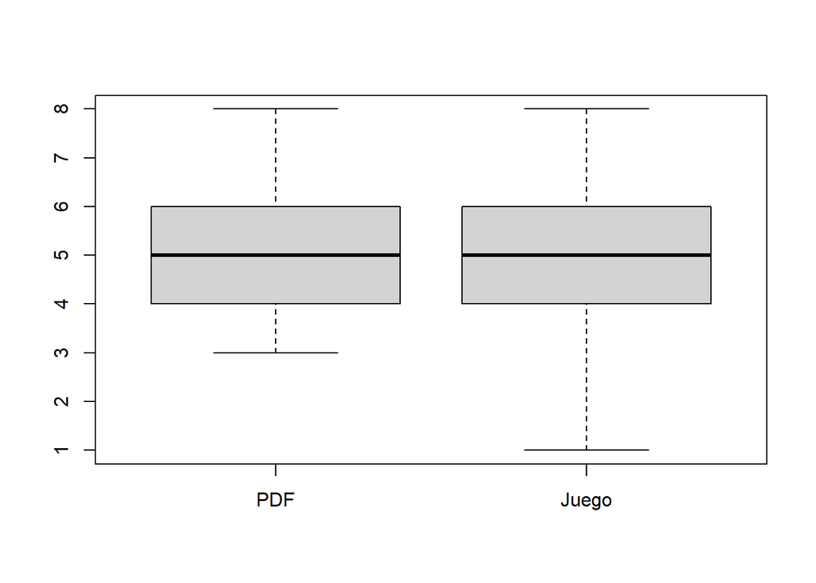

```r
data <- data.frame(class_learning$score_vector, game_learning_cortado$score_vector)
boxplot(data,names = c("PDF", "Juego"))
```

Con 31 participantes por grupo (62 total) no hemos notado una diferencia significante entre el grupo que paso la experiencia de gamificación y el que no. Como idea intentemos ahora tomar todos los NA como datos no validos

ESTE CODIGO ARREGLA EL PROBLEMA DE “LEER DOCUMENTO” Y “LEER dOCUMENTO PDF”

```r
iterator = 1
for (palabras in DF_M$`Qué experiencia realizaste:`){
  if(!is.na(palabras)){
    if(palabras=="Leer Documento"){
            DF_M$`Qué experiencia realizaste:`[iterator] <- paste0(DF_M$`Qué experiencia realizaste:`[iterator]," PDF")
            #print(iterator)
      }
    }

    iterator = iterator + 1
}
DF_M$`Qué experiencia realizaste:`
```

```
##  [1] "Leer Documento PDF" "Leer Documento PDF" "Leer Documento PDF"
##  [4] "Leer Documento PDF" "Leer Documento PDF" "Leer Documento PDF"
##  [7] "Jugar PC Simulator" "Jugar PC Simulator" "Jugar PC Simulator"
## [10] "Jugar PC Simulator" "Leer Documento PDF" "Leer Documento PDF"
## [13] "Jugar PC Simulator" "Jugar PC Simulator" "Jugar PC Simulator"
## [16] "Leer Documento PDF" "Jugar PC Simulator" "Jugar PC Simulator"
## [19] "Jugar PC Simulator" "Jugar PC Simulator" "Jugar PC Simulator"
## [22] "Leer Documento PDF" "Jugar PC Simulator" "Leer Documento PDF"
## [25] "Jugar PC Simulator" "Jugar PC Simulator" "Jugar PC Simulator"
## [28] "Jugar PC Simulator" "Jugar PC Simulator" "Jugar PC Simulator"
## [31] "Jugar PC Simulator" "Jugar PC Simulator" "Leer Documento PDF"
## [34] "Jugar PC Simulator" "Jugar PC Simulator" "Jugar PC Simulator"
## [37] "Leer Documento PDF" "Jugar PC Simulator" "Jugar PC Simulator"
## [40] "Leer Documento PDF" "Jugar PC Simulator" "Jugar PC Simulator"
## [43] "Leer Documento PDF" "Jugar PC Simulator" "Jugar PC Simulator"
## [46] "Jugar PC Simulator" "Leer Documento PDF" "Leer Documento PDF"
## [49] "Leer Documento PDF" "Jugar PC Simulator" "Jugar PC Simulator"
## [52] "Jugar PC Simulator" "Leer Documento PDF" "Jugar PC Simulator"
## [55] "Jugar PC Simulator" "Leer Documento PDF" "Leer Documento PDF"
## [58] "Leer Documento PDF" "Leer Documento PDF" "Leer Documento PDF"
## [61] "Jugar PC Simulator" "Jugar PC Simulator" "Leer Documento PDF"
## [64] "Leer Documento PDF" "Leer Documento PDF" "Leer Documento PDF"
## [67] "Leer Documento PDF" "Leer Documento PDF" "Jugar PC Simulator"
## [70] "Leer Documento PDF" "Leer Documento PDF" "Leer Documento PDF"
## [73] "Leer Documento PDF" "Leer Documento PDF" "Leer Documento PDF"
## [76] "Jugar PC Simulator" "Jugar PC Simulator" "Jugar PC Simulator"
## [79] "Jugar PC Simulator" "Leer Documento PDF" "Jugar PC Simulator"
## [82] "Jugar PC Simulator" "Jugar PC Simulator" "Jugar PC Simulator"
## [85] NA
```

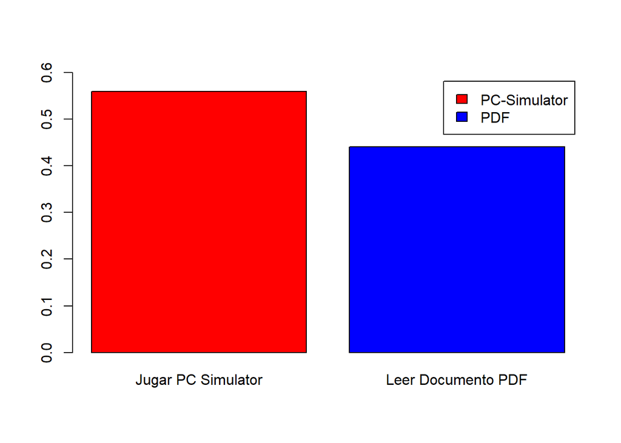

```r
barplot(prop.table(table(DF_M$`Qué experiencia realizaste:`)),col=c("red","blue"),legend.text=c("PC-Simulator","PDF"),ylim=c(0,0.6))
```

```r
#unique(DF_M$`Qué experiencia realizaste:`)
? barplot()
```

```
## starting httpd help server ... done
```